# Candy Production Forecasting v.HTMLNote

Edward Lee

May 31, 2023

```r
# Load necessary packages
library(tseries)
library(fpp)
```

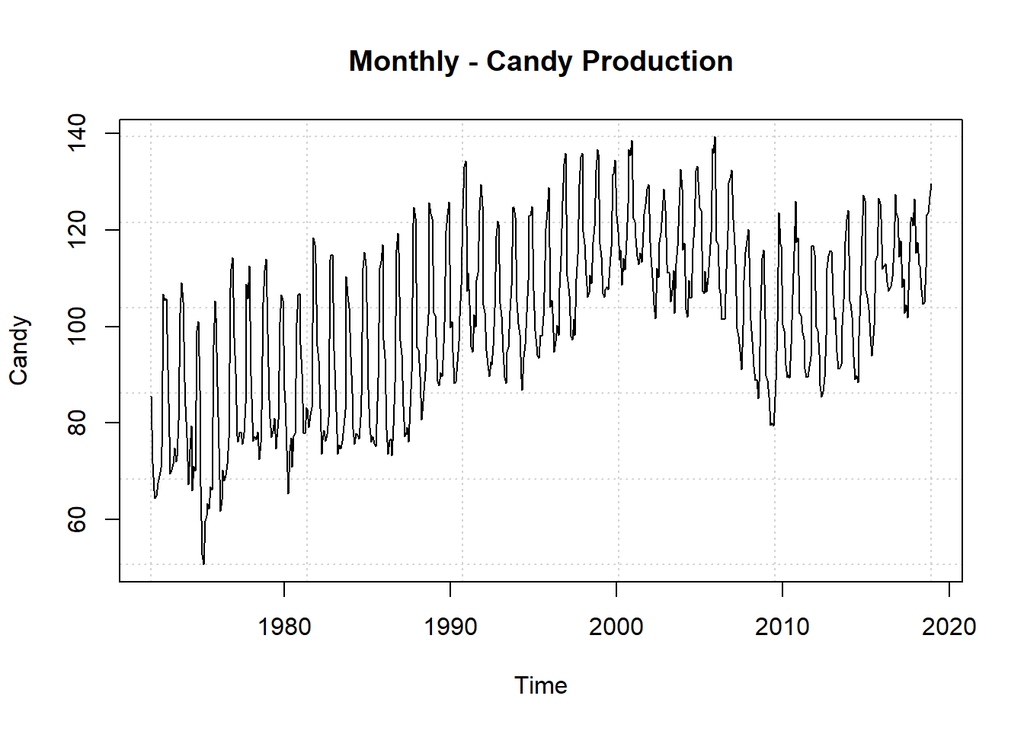

```r
library(ggplot2)
library(forecast)
library(TSA)
library(vars)
setwd("C:/Users/mars_/Documents/Rcode")
# Load candy dataset
candy_production <- read.csv('candy_production.csv')
# Load personal consumption expenditures dataset
consumption_expense <- read.csv('PCE.csv')
consumption_expense <- consumption_expense[157:720,]
# Create time series objects
candy_ts <- ts(candy_production$IPG3113N, start=c(1972,1), frequency=12)
consumption_ts <- ts(consumption_expense$PCE, start=c(1972,1), frequency=12)
data_ts <- cbind(candy_ts,consumption_ts)
# Plot them
plot(candy_ts, ylab = "Candy", main="Monthly - Candy Production", panel.first = grid())
```

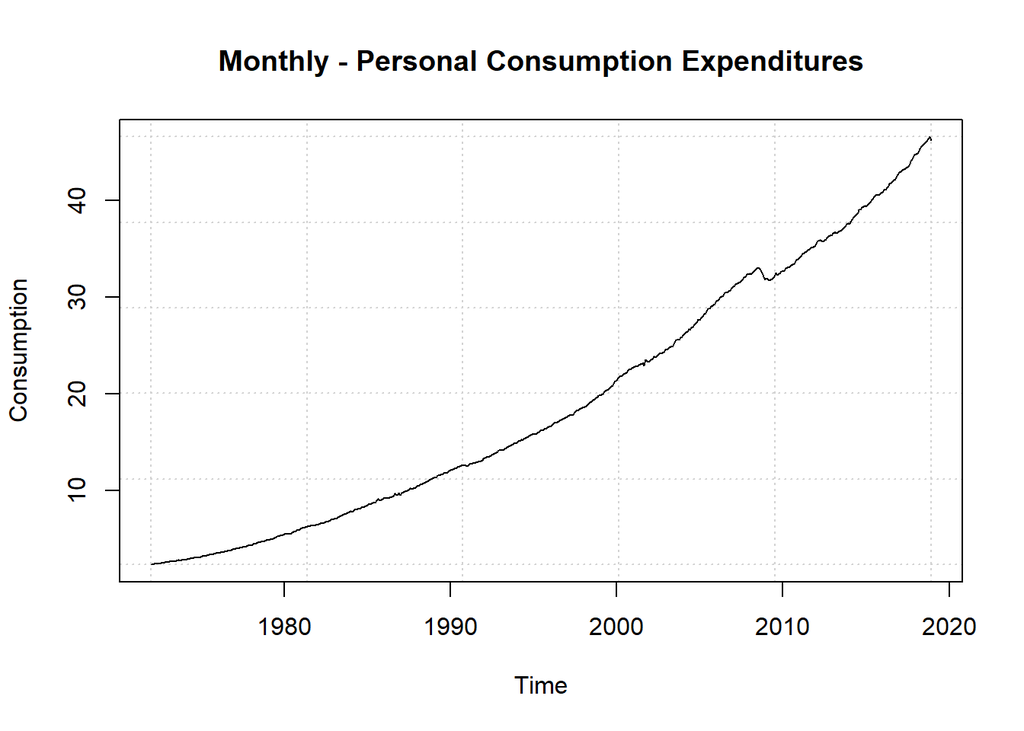

```r
plot(consumption_ts, ylab = "Consumption", main="Monthly - Personal Consumption Expenditures", panel.first = grid())
```

```r
# Split dataset into training and test
training_ts <- window(candy_ts, start=c(1972,1), end=c(2017,12), f=12)
test_ts <- window(candy_ts, start=c(2018,1), end=c(2018,12), f=12)
training_con_ts <- window(consumption_ts, start=c(1972,1), end=c(2017,12), f=12)
test_con_ts <- window(consumption_ts, start=c(2018,1), end=c(2018,12), f=12)
```

Box-Cox transformation is necessary for this data, since the data in the plot shows variance is unstable with the level of the series. We can also see that the data has seasonality ans slightly upward trend. After applying Box-Cox transformation, the variance is stablized.

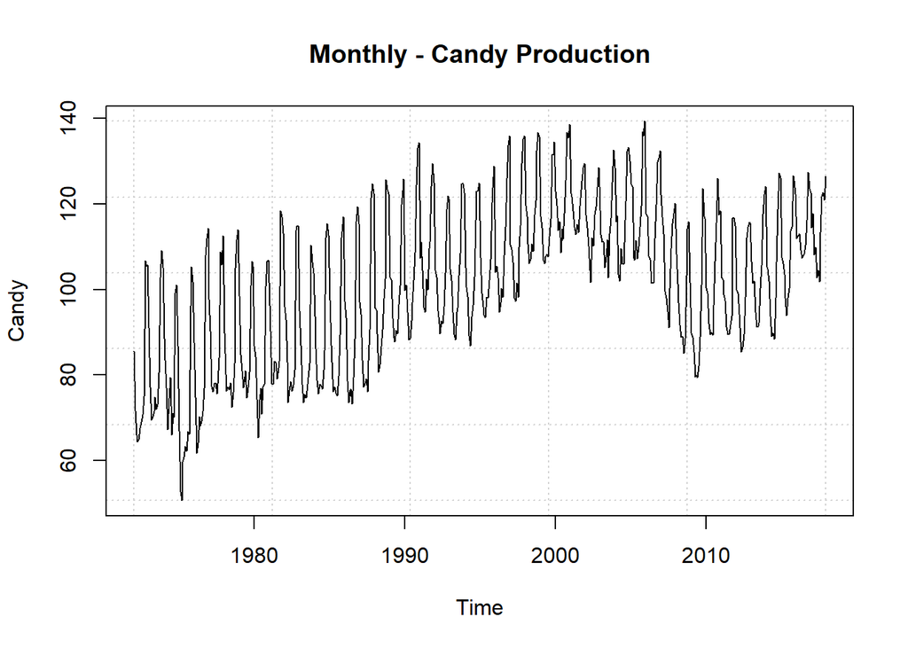

```r
plot(training_ts, ylab = "Candy", main="Monthly - Candy Production", panel.first = grid())
```

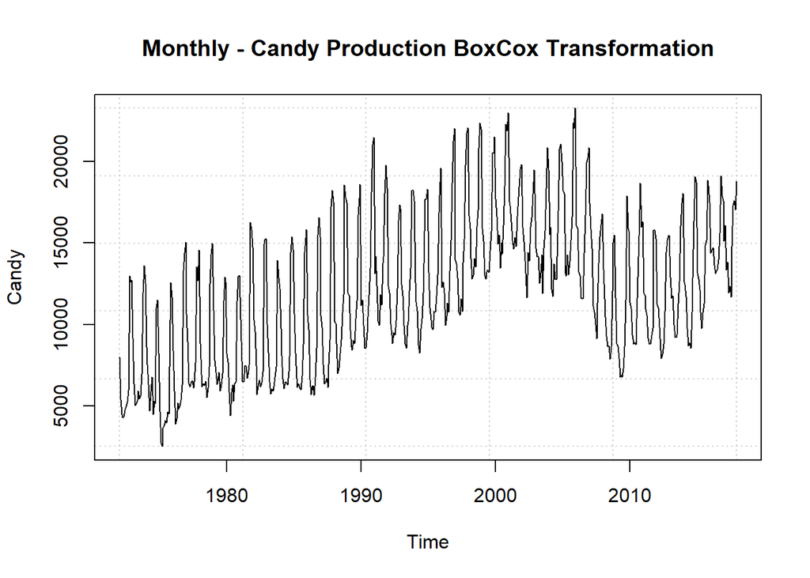

```r
lmd <- BoxCox.lambda(training_ts, upper = 3)
lmd1 <- BoxCox.lambda(consumption_ts)
plot(training_ts %>% BoxCox(lambda = lmd), ylab = "Candy", main="Monthly - Candy Production BoxCox Transformation", panel.first = grid())
```

```r
data_ts <- cbind(data_ts,"transCandy" = candy_ts %>% BoxCox(lambda = lmd), "transCon" = consumption_ts %>% BoxCox(lambda = lmd1))
```

Our goal here is to ensure the training ts and exogenous variable are both stationary.  
After applying a seasonal difference on the training time series, we still see some seasonality in the ACF plot. After applying non-seasonal differenceing, although some spikes appeared in both ACF and PACF plots, the majority of lags are within the threshold range.  
For the exogenous variable, we apply Box-Cox transformation since the variance is not stable. After applying non-seasonal differenceing, the majority of lags are within the threshold range.

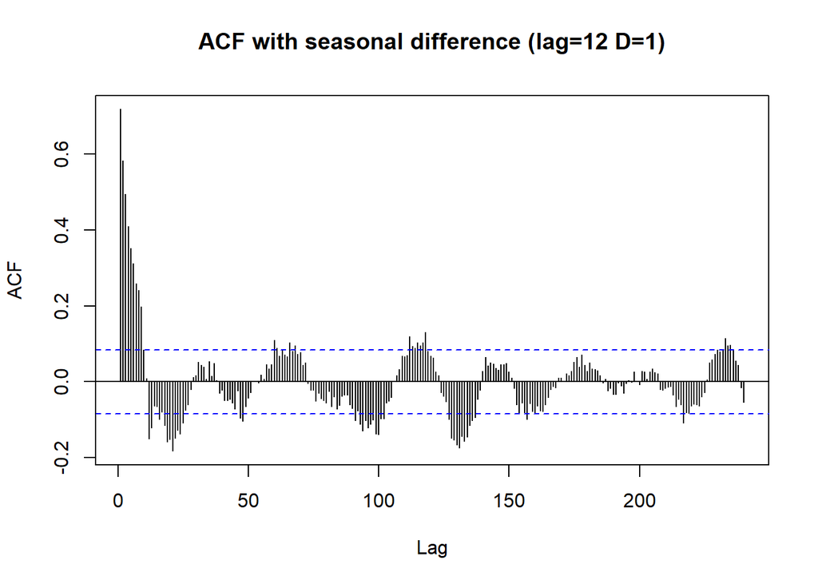

```r
# Apply Box Cox transformation, and take a seasonal difference on the data
training_ts_t <- diff(training_ts %>% BoxCox(lambda = lmd), lag=12)
Acf(training_ts_t, lag.max = 240, main="ACF with seasonal difference (lag=12 D=1)")
```

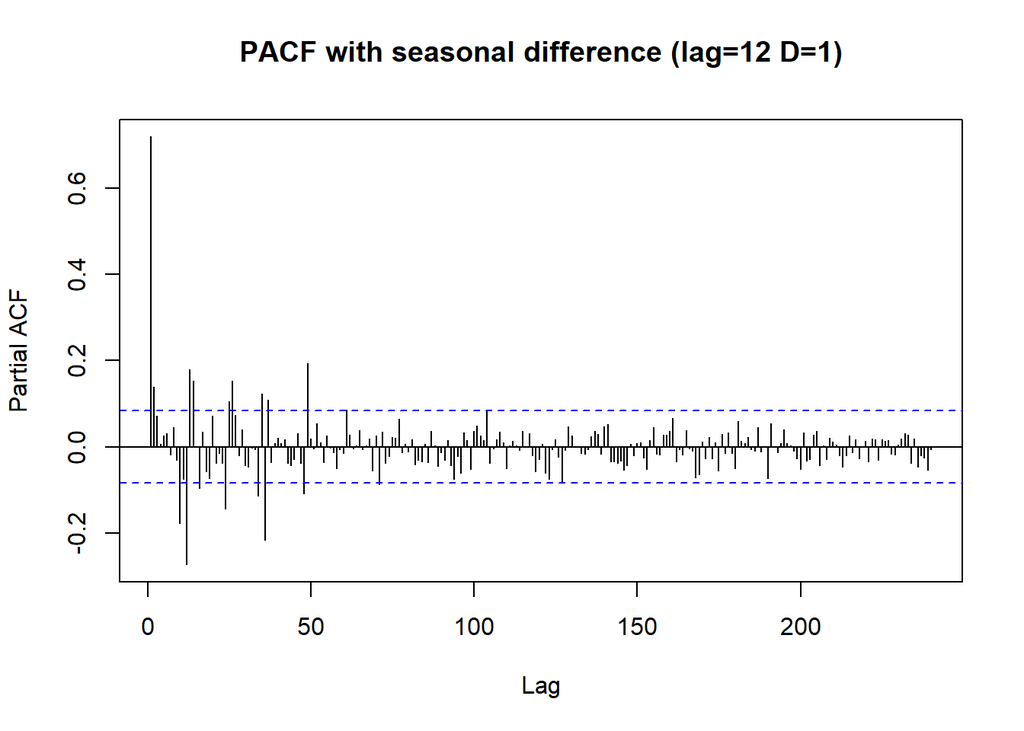

```r
Pacf(training_ts_t, lag.max = 240, main="PACF with seasonal difference (lag=12 D=1)")
```

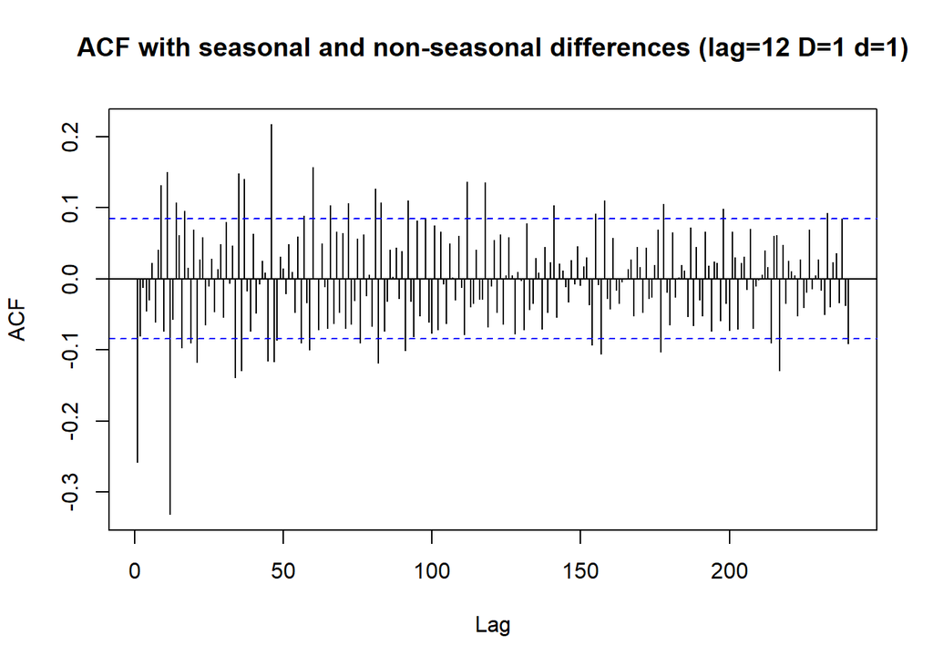

```r
# Apply first order diff on seasonal difference as there is some seasonality in first order ACF plot
training_ts_t2 <- diff(training_ts_t)
Acf(training_ts_t2, lag.max = 240, main="ACF with seasonal and non-seasonal differences (lag=12 D=1 d=1)")
```

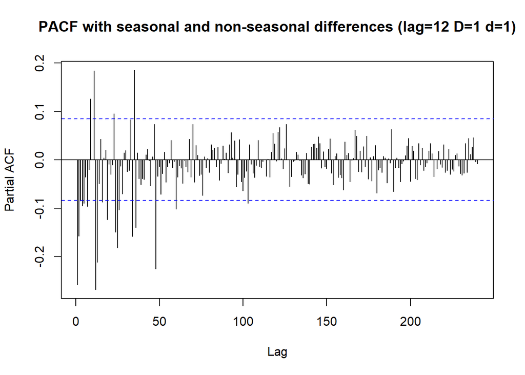

```r
Pacf(training_ts_t2, lag.max = 240, main="PACF with seasonal and non-seasonal differences (lag=12 D=1 d=1)")
```

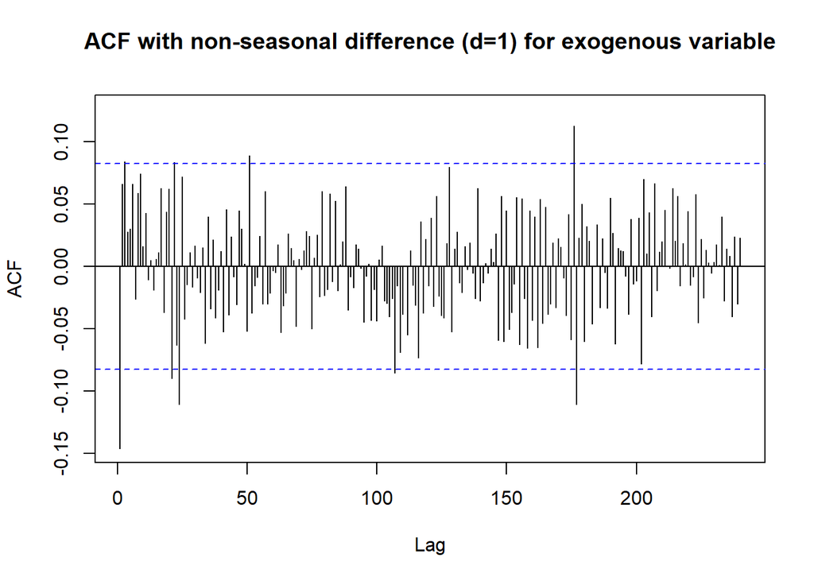

```r
# Apply Box Cox transformation, and take a non-seasonal difference on the exogenous variable
# since there is no seasonal pattern on this dataset
consumption_ts_t <- diff(consumption_ts %>% BoxCox(lambda = lmd1))
Acf(consumption_ts_t, lag.max = 240, main="ACF with non-seasonal difference (d=1) for exogenous variable")
```

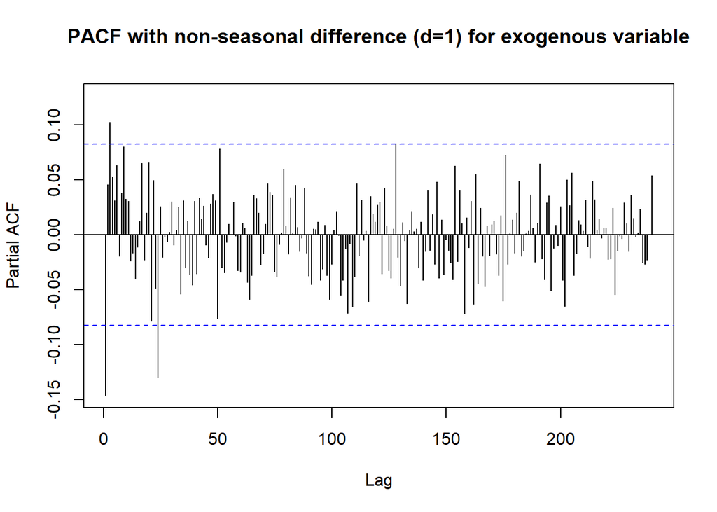

```r
Pacf(consumption_ts_t, lag.max = 240, main="PACF with non-seasonal difference (d=1) for exogenous variable")
```

Both KPSS and ADF plots confirm the transformed training dataset and exogenous variable are now stationary.

```r
kpss.test(training_ts_t2)
# p-value = 0.1 > 0.05 ==> Accept Null hypothesis ==> The process is stationary.
adf.test(training_ts_t2)
```

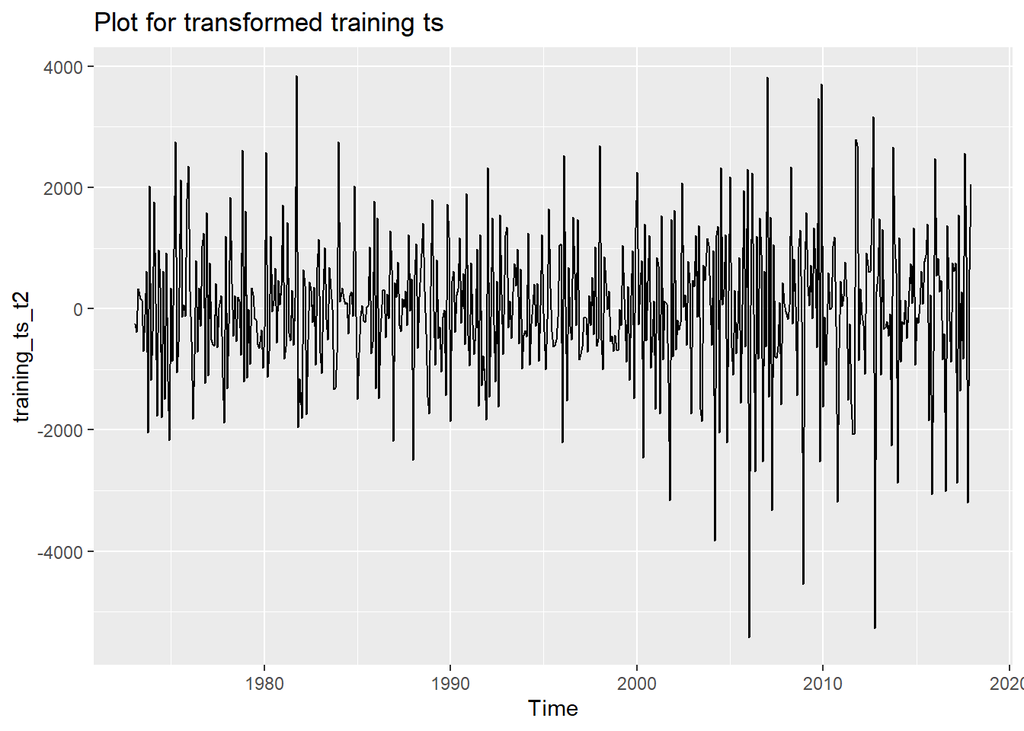

```r
# p-value = 0.01 < 0.05 ==> Accept alternative hypothesis ==> The process is stationary.
autoplot(training_ts_t2, main="Plot for transformed training ts")
```

```r
kpss.test(consumption_ts_t)
# p-value = 0.1 > 0.05 ==> Accept Null hypothesis ==> The process is stationary.
adf.test(consumption_ts_t)
```

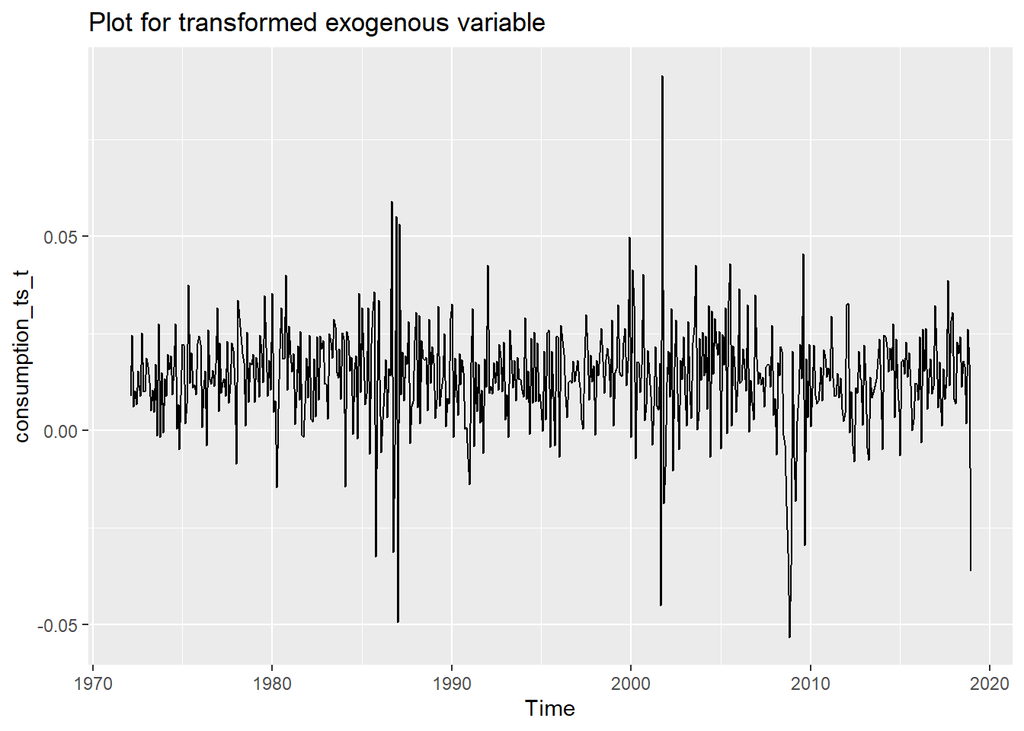

```
    KPSS Test for Level Stationarity

data:  training_ts_t2
KPSS Level = 0.012057, Truncation lag parameter = 6, p-value = 0.1


    Augmented Dickey-Fuller Test

data:  training_ts_t2
Dickey-Fuller = -8.5392, Lag order = 8, p-value = 0.01
alternative hypothesis: stationary


    KPSS Test for Level Stationarity

data:  consumption_ts_t
KPSS Level = 0.2281, Truncation lag parameter = 6, p-value = 0.1


    Augmented Dickey-Fuller Test

data:  consumption_ts_t
Dickey-Fuller = -6.2219, Lag order = 8, p-value = 0.01
alternative hypothesis: stationary
```

```r
# p-value = 0.01 < 0.05 ==> Accept alternative hypothesis ==> The process is stationary.
autoplot(consumption_ts_t, main="Plot for transformed exogenous variable")
```

Fit sarima model and test if residuals resemble white noise. Here, we assign trace outputs to a data frame and selct top 8 sarima models based on AICc. The reason we are doing this way is to ensure the model we pick not only has low AICc value but its residuals resemble white noise. Also, we need to ensure all the coefficients are significant. When comparing the best two models, although AICc is slighter lower for ARIMA(2,1,3)(0,1,2)[12], the coefficients for MA1 are not significant from zero, while all coefficients for ARIMA(2,1,2)(0,1,2)[12] are significant from zero. Therefore, we prefer ARIMA(2,1,2)(0,1,2)[12] over ARIMA(2,1,3)(0,1,2)[12]. The order of final sarima model is ARIMA(2,1,2)(0,1,2)[12]. The Ljung-Box test has p value greater than 5%, which indicates the residuals are white noise. The Shapiro-Wilk test has p value less than 5%, which indicates the residuals are not normally distributed.

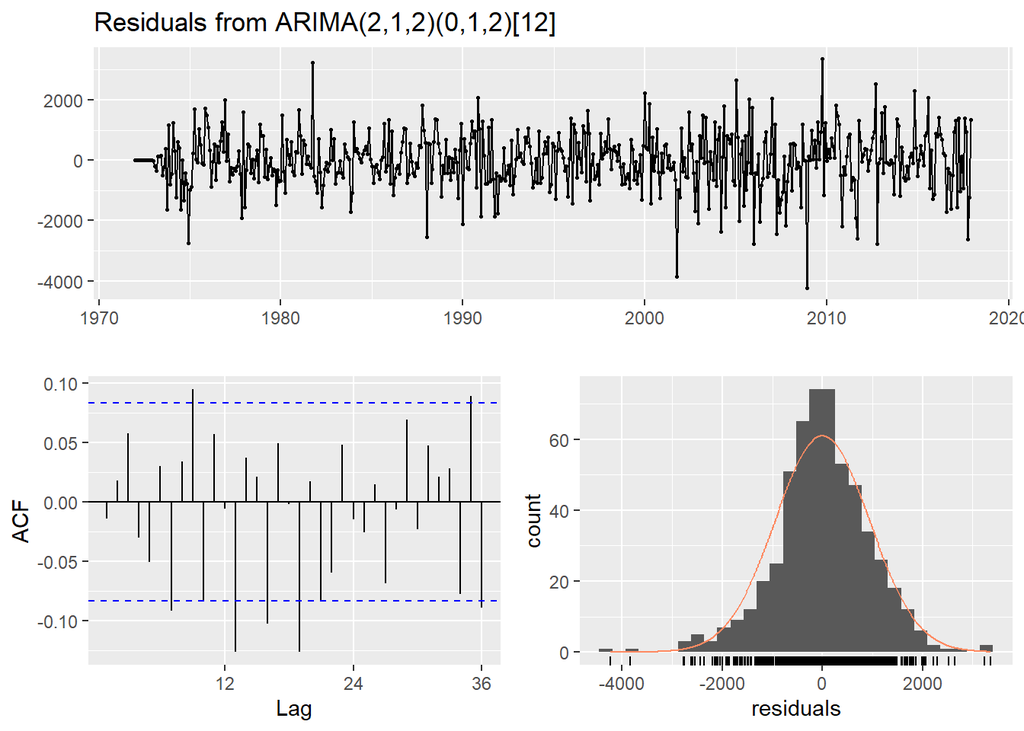

```r
# Assign trace outputs to a data frame and selct top 8 sarima models based on AICc
trace <- capture.output({
    # Set d = 1 as we believe the first and seasonal difference can take off the seasonality on ACF plot
    fit_arima <- auto.arima(training_ts, d = 1, seasonal=TRUE, lambda = lmd, trace = TRUE)
})
con <- textConnection(trace)
fit_arimas <- read.table(con, sep=":", fill=TRUE, row.names = NULL)
fit_arimas <- fit_arimas[2:(length(fit_arimas[,1])-3),]
colnames(fit_arimas) <- c("arima model","AICc approx.")
fit_arimas8 <- fit_arimas[order(fit_arimas[,2]),][1:8,]
fit_arimas8
close(con)

# Fit top 8 sarima models and collect Ljung-Box and Shapiro test results
fit_arima1 <- Arima(training_ts, order = c(1,1,2), seasonal = c(0,1,2), lambda = lmd)
Box.test(fit_arima1$residuals, lag = 12, type = "Ljung")
shapiro.test(fit_arima1$residuals)
fit_arima2 <- Arima(training_ts, order = c(1,1,3), seasonal = c(0,1,2), lambda = lmd)
Box.test(fit_arima2$residuals, lag = 12, type = "Ljung")
shapiro.test(fit_arima2$residuals)
fit_arima3 <- Arima(training_ts, order = c(1,1,1), seasonal = c(0,1,2), lambda = lmd)
Box.test(fit_arima3$residuals, lag = 12, type = "Ljung")
shapiro.test(fit_arima3$residuals)
fit_arima4 <- Arima(training_ts, order = c(0,1,2), seasonal = c(0,1,2), lambda = lmd)
Box.test(fit_arima4$residuals, lag = 12, type = "Ljung")
shapiro.test(fit_arima4$residuals)
fit_arima5 <- Arima(training_ts, order = c(2,1,3), seasonal = c(0,1,2), lambda = lmd)
Box.test(fit_arima5$residuals, lag = 12, type = "Ljung")
shapiro.test(fit_arima5$residuals)
fit_arima6 <- Arima(training_ts, order = c(2,1,1), seasonal = c(0,1,2), lambda = lmd)
Box.test(fit_arima6$residuals, lag = 12, type = "Ljung")
shapiro.test(fit_arima6$residuals)
fit_arima7 <- Arima(training_ts, order = c(0,1,3), seasonal = c(0,1,2), lambda = lmd)
Box.test(fit_arima7$residuals, lag = 12, type = "Ljung")
shapiro.test(fit_arima7$residuals)
fit_arima8 <- Arima(training_ts, order = c(2,1,2), seasonal = c(0,1,2), lambda = lmd)
Box.test(fit_arima8$residuals, lag = 12, type = "Ljung")
shapiro.test(fit_arima8$residuals)

# Two models are left based on their low AICc value and residuals resembling white noise.
# They are ARIMA(2,1,2)(0,1,2)[12] and ARIMA(2,1,3)(0,1,2)[12].
# Let's start with simple model first: ARIMA(2,1,2)(0,1,2)[12].
summary(fit_arima8)
# Then ARIMA(2,1,3)(0,1,2)[12].
summary(fit_arima5)
# When comparing the two models, although AICc is slighter lower for ARIMA(2,1,3)(0,1,2)[12],
# the coefficients for ma1 are not significant from zero, while all coefficients for
# ARIMA(2,1,2)(0,1,2)[12] are significant from zero. Therefore, we prefer ARIMA(2,1,2)(0,1,2)[12]
# over ARIMA(2,1,3)(0,1,2)[12].
fit_arima <- Arima(training_ts, order = c(2,1,2), seasonal = c(0,1,2), lambda = lmd)
summary(fit_arima)
checkresiduals(fit_arima)
```

```r
# Ljung-Box test testing residuals' white noise
Box.test(fit_arima$residuals, lag = 12, type = "Ljung")
# Shapiro test testing residuals' normality
shapiro.test(fit_arima$residuals)
```

```
                                    arima model AICc approx.
10  ARIMA(1,1,2)(0,1,2)[12]                         8764.567
16  ARIMA(1,1,3)(0,1,2)[12]                         8764.943
15  ARIMA(1,1,1)(0,1,2)[12]                         8765.354
14  ARIMA(0,1,2)(0,1,2)[12]                         8766.706
20  ARIMA(2,1,3)(0,1,2)[12]                         8767.076
19  ARIMA(2,1,1)(0,1,2)[12]                         8767.231
18  ARIMA(0,1,3)(0,1,2)[12]                          8768.47
9   ARIMA(2,1,2)(0,1,2)[12]                         8769.792

    Box-Ljung test

data:  fit_arima1$residuals
X-squared = 23.477, df = 12, p-value = 0.02394


    Shapiro-Wilk normality test

data:  fit_arima1$residuals
W = 0.98087, p-value = 1.233e-06


    Box-Ljung test

data:  fit_arima2$residuals
X-squared = 23.26, df = 12, p-value = 0.0256


    Shapiro-Wilk normality test

data:  fit_arima2$residuals
W = 0.98014, p-value = 7.899e-07


    Box-Ljung test

data:  fit_arima3$residuals
X-squared = 23.092, df = 12, p-value = 0.02695


```

[output cut: 120 more lines]

```
Q* = 54.993, df = 18, p-value = 1.284e-05

Model df: 6.   Total lags used: 24


    Box-Ljung test

data:  fit_arima$residuals
X-squared = 20.724, df = 12, p-value = 0.05457


    Shapiro-Wilk normality test

data:  fit_arima$residuals
W = 0.98284, p-value = 4.321e-06
```

Check if overfitting problem exists when fitting ARIMA model.  
As we can tell, the coefficients change after decreasing p or q by 1. The model assumption is changed if coefficients change. Therefore, we conclude the overfitting problem does not exist in the fitted ARIMA model.

```r
# Decrease q by 1
fit_arimaA <- Arima(training_ts, order = c(2,1,1), seasonal = c(0,1,2), lambda = lmd)
summary(fit_arimaA)
# Decrease p by 1
fit_arimaB <- Arima(training_ts, order = c(1,1,2), seasonal = c(0,1,2), lambda = lmd)
summary(fit_arimaB)
```

```
Series: training_ts
ARIMA(2,1,1)(0,1,2)[12]
Box Cox transformation: lambda= 2.196103

Coefficients:
         ar1     ar2      ma1     sma1     sma2
      0.4705  0.0547  -0.8287  -0.6384  -0.1627
s.e.  0.1006  0.0669   0.0892   0.0440   0.0430

sigma^2 estimated as 927711:  log likelihood=-4471.14
AIC=8954.28   AICc=8954.44   BIC=8980.02

Training set error measures:
                      ME    RMSE      MAE         MPE     MAPE      MASE
Training set -0.01468744 3.66279 2.785776 -0.09070972 2.839317 0.5443927
                   ACF1
Training set 0.02331497
Series: training_ts
ARIMA(1,1,2)(0,1,2)[12]
Box Cox transformation: lambda= 2.196103

Coefficients:
         ar1      ma1     ma2     sma1     sma2
      0.7628  -1.1371  0.2026  -0.6291  -0.1654
s.e.  0.1623   0.1838  0.1178   0.0456   0.0431

sigma^2 estimated as 926106:  log likelihood=-4470.72
AIC=8953.44   AICc=8953.6   BIC=8979.18

Training set error measures:
                       ME     RMSE      MAE        MPE     MAPE      MASE
Training set -0.008448067 3.654785 2.771566 -0.0859038 2.823008 0.5416159
                   ACF1
Training set 0.03208989
```

We will plot the forecast for sarima model.

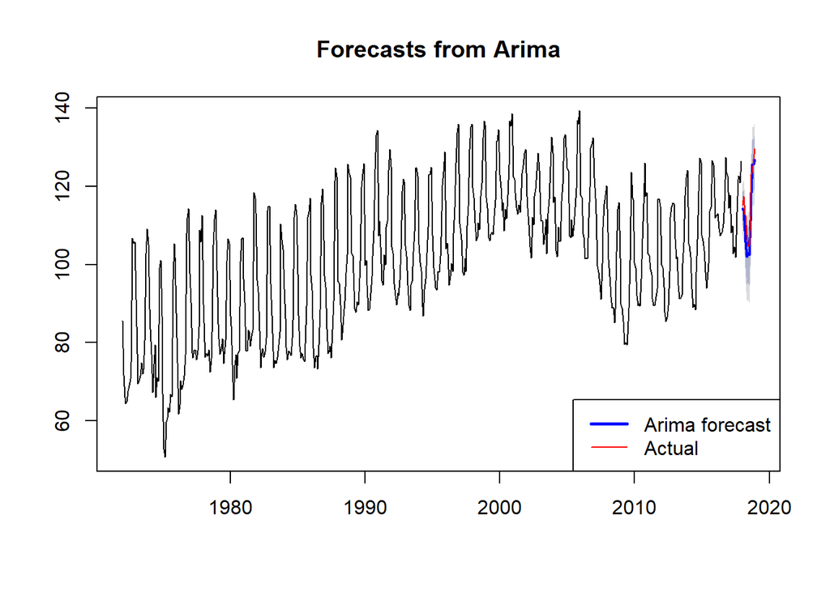

```r
# Forecast with Arima
predict_arima <- forecast(fit_arima, h = 12)

# Plot the forecasts from Arima
plot(predict_arima , main = "Forecasts from Arima")
lines(test_ts, col = "red")
legend("bottomright",legend=c("Arima forecast","Actual"),col = c("blue", "red"), lwd=c(2.5,1), lty=1)
```

Calculate MAPE and MSE for sarima to evaluate model performance.

```r
# Calculate MAPE and MSE for arima
MAPE_arima <- 100*sum(abs(predict_arima$mean-test_ts)/test_ts)/length(test_ts)
MSE_arima <- sum((predict_arima$mean-test_ts)^2)/length(test_ts)
```

Fit ets model and test if residuals resemble white noise. The order of ets model is ETS(A,N,A). The Ljung-Box test has p value less than 5%, which indicates the residuals are not white noise. The Shapiro-Wilk test has p value less than 5%, which indicates the residuals are not normally distributed.

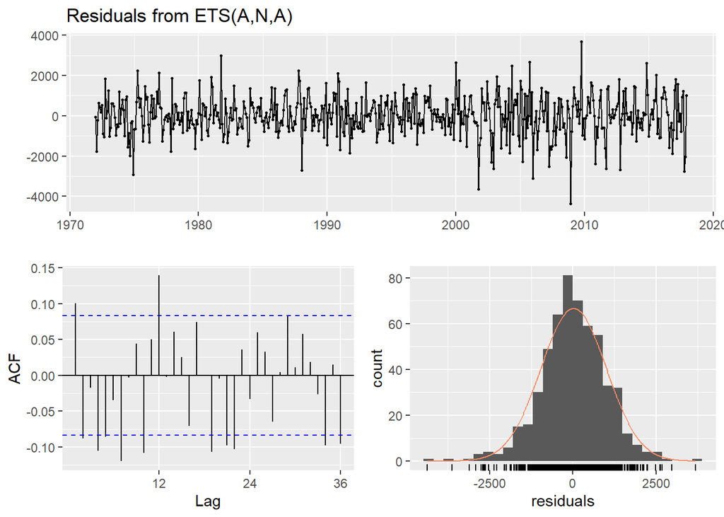

```r
# Fit ets model
fit_ets <- ets(training_ts, lambda = lmd)
summary(fit_ets)
checkresiduals(fit_ets)
```

```r
# Ljung-Box test testing residuals' white noise
Box.test(fit_ets$residuals, lag = 12, type = "Ljung")
# Shapiro test testing residuals' normality
shapiro.test(fit_ets$residuals)
```

```
ETS(A,N,A)

Call:
 ets(y = training_ts, lambda = lmd)

  Box-Cox transformation: lambda= 2.1961

  Smoothing parameters:
    alpha = 0.5258
    gamma = 0.2142

  Initial states:
    l = 7658.2251
    s = 5045.728 5238.631 4616.687 -63.7492 -1399.736 -2825.793
           -2587.119 -2997.739 -2959.427 -1992.25 -454.3799 379.1474

  sigma:  999.9665

     AIC     AICc      BIC
11127.02 11127.92 11191.73

Training set error measures:
                     ME     RMSE     MAE       MPE     MAPE      MASE      ACF1
Training set 0.09619965 3.940461 3.01439 0.0318344 3.143738 0.5890683 0.1466396

    Ljung-Box test

data:  Residuals from ETS(A,N,A)
Q* = 77.415, df = 10, p-value = 1.609e-12

Model df: 14.   Total lags used: 24


    Box-Ljung test

data:  fit_ets$residuals
X-squared = 49.286, df = 12, p-value = 1.864e-06


    Shapiro-Wilk normality test

data:  fit_ets$residuals
W = 0.98641, p-value = 5.1e-05
```

For ets model, the residuals are not white noise and not normally distributed. Nonetheless, we will plot the forecast.

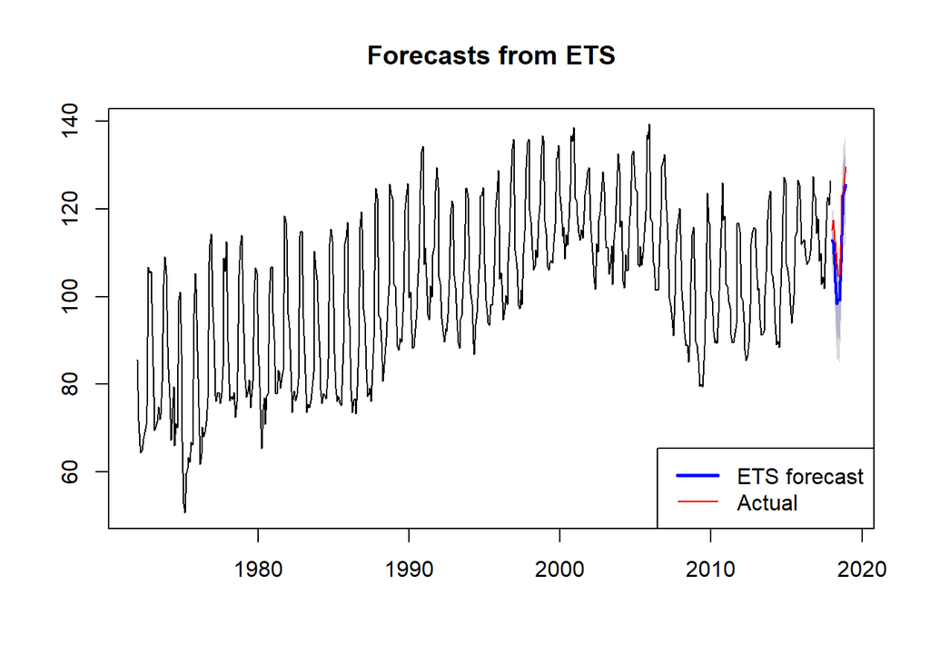

```r
# Forecast with ets
predict_ets <- forecast(fit_ets, h = 12)

# Plot the forecasts from ets
plot(predict_ets , main = "Forecasts from ETS")
lines(test_ts, col = "red")
legend("bottomright",legend=c("ETS forecast","Actual"),col = c("blue", "red"), lwd=c(2.5,1), lty=1)
```

Calculate MAPE and MSE for ets to evaluate model performance.

```r
# Calculate MAPE and MSE for ets
MAPE_ets <- 100*sum(abs(predict_ets$mean-test_ts)/test_ts)/length(test_ts)
MSE_ets <- sum((predict_ets$mean-test_ts)^2)/length(test_ts)
```

Fit linear regression model with personal consumption expenditures as independent variable and candy production as dependent variable, and test if residuals resemble white noise. The Ljung-Box test has p value less than 5%, which indicates the residuals are not white noise. The Shapiro-Wilk test has p value less than 5%, which indicates the residuals are not normally distributed.

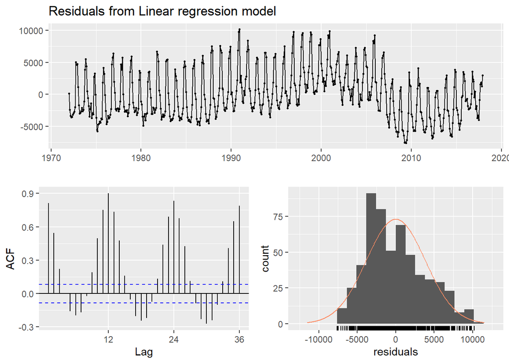

```r
# Fit linear model
fit_lm <- tslm(transCandy ~ transCon, data = window(data_ts, start=c(1972,1), end=c(2017,12), f=12))
summary(fit_lm)
checkresiduals(fit_lm)
```

```r
# Ljung-Box test testing residuals' white noise
Box.test(fit_lm$residuals, lag = 12, type = "Ljung")
# Shapiro test testing residuals' normality
shapiro.test(fit_lm$residuals)
```

```
Call:
tslm(formula = transCandy ~ transCon, data = window(data_ts,
    start = c(1972, 1), end = c(2017, 12), f = 12))

Residuals:
    Min      1Q  Median      3Q     Max
-7624.9 -2920.6  -724.9  2472.2 10184.8

Coefficients:
            Estimate Std. Error t value Pr(>|t|)
(Intercept)  6750.60     398.90   16.92   <2e-16 ***
transCon     1056.96      74.38   14.21   <2e-16 ***
---
Signif. codes:  0 '***' 0.001 '**' 0.01 '*' 0.05 '.' 0.1 ' ' 1

Residual standard error: 3842 on 550 degrees of freedom
Multiple R-squared:  0.2686,    Adjusted R-squared:  0.2672
F-statistic: 201.9 on 1 and 550 DF,  p-value: < 2.2e-16


    Breusch-Godfrey test for serial correlation of order up to 24

data:  Residuals from Linear regression model
LM test = 510.6, df = 24, p-value < 2.2e-16


    Box-Ljung test

data:  fit_lm$residuals
X-squared = 1547, df = 12, p-value < 2.2e-16


    Shapiro-Wilk normality test

data:  fit_lm$residuals
W = 0.96714, p-value = 8.883e-10
```

For linear regression model, the residuals are not white noise and not normally distributed. Nonetheless, we will plot the forecast.

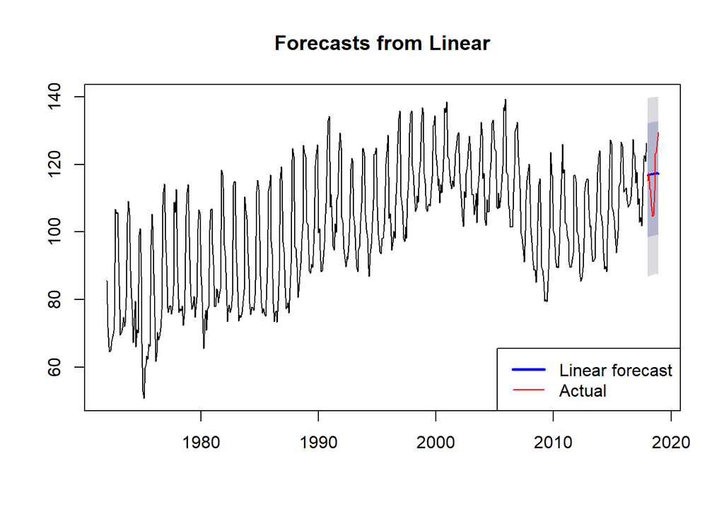

```r
# Forecast with linear
predict_lm <- forecast(fit_lm, newdata = data.frame(transCon=BoxCox(test_con_ts, lambda = lmd1)))
# Revert back the forecasted values to the original scale
predict_lm$mean <- InvBoxCox(predict_lm$mean, lambda = lmd)
predict_lm$upper <- InvBoxCox(predict_lm$upper, lambda = lmd)
predict_lm$lower <- InvBoxCox(predict_lm$lower, lambda = lmd)
predict_lm$x <- InvBoxCox(predict_lm$x, lambda = lmd)

# Plot the forecasts from linear
plot(predict_lm, main = "Forecasts from Linear")
lines(test_ts, col = "red")
legend("bottomright",legend=c("Linear forecast","Actual"),col = c("blue", "red"), lwd=c(2.5,1), lty=1)
```

Calculate MAPE and MSE for linear regression to evaluate model performance.

```r
# Calculate MAPE and MSE for linear regression
MAPE_lm <- 100*sum(abs(predict_lm$mean-test_ts)/test_ts)/length(test_ts)
MSE_lm <- sum((predict_lm$mean-test_ts)^2)/length(test_ts)
```

Fit regression model with ARIMA errors and test if residuals resemble white noise. The order of arima part is ARIMA(2,1,2)(0,1,2)[12]. The Ljung-Box test has p value greater than 5%, which indicates the residuals are white noise. The Shapiro-Wilk test has p value less than 5%, which indicates the residuals are not normally distributed. Note the coeffient for xreg is not significant from 0.

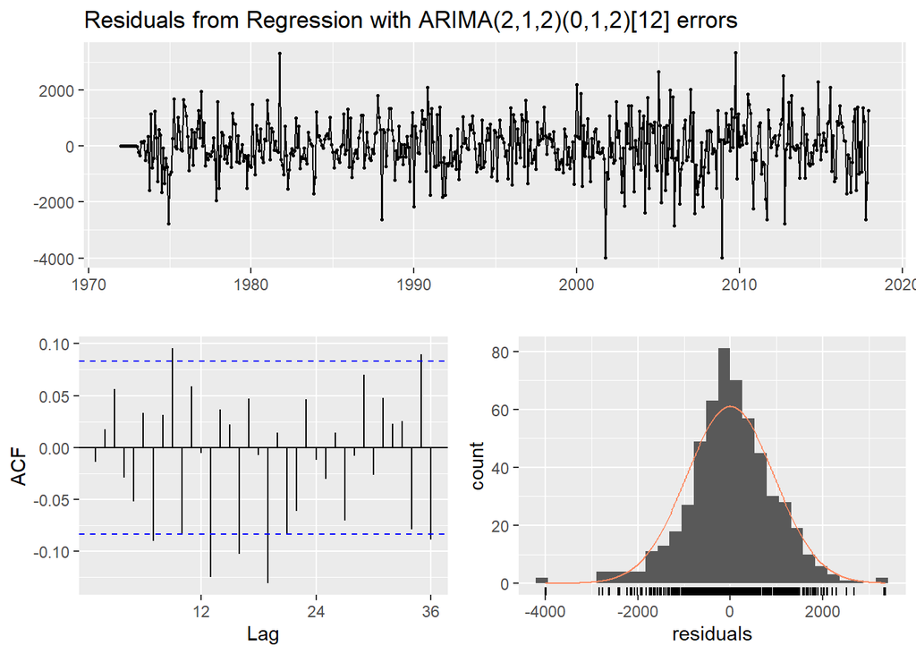

```r
# Fit regression model with ARIMA errors
fit_xreg <- Arima(training_ts, order = c(2,1,2), seasonal = c(0,1,2), xreg = BoxCox(training_con_ts, lambda = lmd1), lambda = lmd)
summary(fit_xreg)
checkresiduals(fit_xreg)
```

```r
# Ljung-Box test testing residuals' white noise
Box.test(fit_xreg$residuals, lag = 12, type = "Ljung")
# Shapiro test testing residuals' normality
shapiro.test(fit_xreg$residuals)
```

```
Series: training_ts
Regression with ARIMA(2,1,2)(0,1,2)[12] errors
Box Cox transformation: lambda= 2.196103

Coefficients:
          ar1     ar2     ma1      ma2     sma1     sma2      xreg
      -0.5413  0.3809  0.1988  -0.7369  -0.6379  -0.1587  2518.041
s.e.   0.0969  0.0929  0.0759   0.0728   0.0440   0.0430  2560.847

sigma^2 estimated as 928077:  log likelihood=-4470.29
AIC=8956.57   AICc=8956.84   BIC=8990.89

Training set error measures:
                      ME     RMSE      MAE         MPE     MAPE      MASE
Training set -0.01332264 3.669127 2.791174 -0.08610923 2.850095 0.5454477
                   ACF1
Training set 0.01562079

    Ljung-Box test

data:  Residuals from Regression with ARIMA(2,1,2)(0,1,2)[12] errors
Q* = 55.32, df = 17, p-value = 6.088e-06

Model df: 7.   Total lags used: 24


    Box-Ljung test

data:  fit_xreg$residuals
X-squared = 20.736, df = 12, p-value = 0.05438


    Shapiro-Wilk normality test

data:  fit_xreg$residuals
W = 0.98255, p-value = 3.579e-06
```

Check if overfitting problem exists when fitting regression model with ARIMA errors.  
As we can tell, the coefficients change after decreasing p or q by 1. The model assumption is changed if coefficients change. Therefore, we conclude the overfitting problem does not exist in the fitted regression model with ARIMA errors.

```r
# Decrease q by 1
fit_xregA <- Arima(training_ts, order = c(2,1,1), seasonal = c(0,1,2), xreg = BoxCox(training_con_ts, lambda = lmd1), lambda = lmd)
summary(fit_xregA)
# Decrease p by 1
fit_xregB <- Arima(training_ts, order = c(1,1,2), seasonal = c(0,1,2), xreg = BoxCox(training_con_ts, lambda = lmd1), lambda = lmd)
summary(fit_xregB)
```

```
Series: training_ts
Regression with ARIMA(2,1,1)(0,1,2)[12] errors
Box Cox transformation: lambda= 2.196103

Coefficients:
         ar1     ar2      ma1     sma1     sma2      xreg
      0.4703  0.0533  -0.8308  -0.6418  -0.1583  2379.350
s.e.  0.1010  0.0675   0.0896   0.0441   0.0433  2538.072

sigma^2 estimated as 927986:  log likelihood=-4470.7
AIC=8955.41   AICc=8955.62   BIC=8985.43

Training set error measures:
                      ME     RMSE      MAE         MPE     MAPE     MASE
Training set -0.01399634 3.660387 2.785224 -0.09016293 2.841778 0.544285
                   ACF1
Training set 0.02471137
Series: training_ts
Regression with ARIMA(1,1,2)(0,1,2)[12] errors
Box Cox transformation: lambda= 2.196103

Coefficients:
         ar1      ma1     ma2     sma1     sma2      xreg
      0.7661  -1.1434  0.2054  -0.6318  -0.1609  2390.010
s.e.  0.1464   0.1682  0.1109   0.0454   0.0432  2503.634

sigma^2 estimated as 926301:  log likelihood=-4470.27
AIC=8954.54   AICc=8954.75   BIC=8984.57

Training set error measures:
                      ME     RMSE      MAE         MPE     MAPE      MASE
Training set -0.00602533 3.651862 2.769052 -0.08370176 2.823529 0.5411246
                   ACF1
Training set 0.03365332
```

We will plot the forecast for regression model with ARIMA errors model.

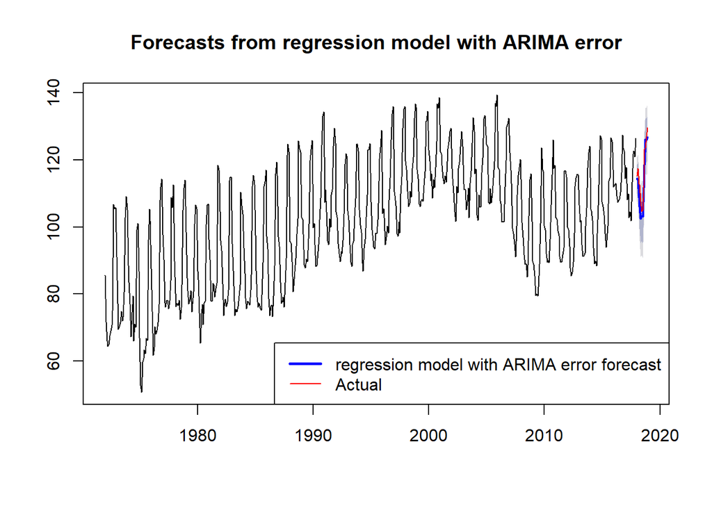

```r
# Forecast with regression model with ARIMA errors
# Here, for xreg I use the test data from consumption since it's given.
# Theoretically the forecast for xreg has to be forecasted with a ts model.
predict_xreg <- forecast(fit_xreg, xreg = BoxCox(test_con_ts, lambda = lmd1), h = 12)

# Plot the forecasts from regression model with ARIMA errors
plot(predict_xreg , main = "Forecasts from regression model with ARIMA error")
lines(test_ts, col = "red")
legend("bottomright",legend=c("regression model with ARIMA error forecast","Actual"),col = c("blue", "red"), lwd=c(2.5,1), lty=1)
```

Calculate MAPE and MSE for regression model with ARIMA error to evaluate model performance.

```r
# Calculate MAPE and MSE for regression model with ARIMA error
MAPE_xreg <- 100*sum(abs(predict_xreg$mean-test_ts)/test_ts)/length(test_ts)
MSE_xreg <- sum((predict_xreg$mean-test_ts)^2)/length(test_ts)
```

Fit VAR model and test if residuals resemble white noise. The VAR model is VAR(5). The serial.test has p value less than 5%, which indicates the residuals are not white noise. The Shapiro-Wilk test has p value less than 5%, which indicates the residuals are not normally distributed.

```r
# Pick out lag length with Varselect function
VARselect(window(data_ts, start=c(1972,1), end=c(2017,12), f=12)[,3:4], type = "both", season = 12)$selection
# AIC(n)  HQ(n)  SC(n) FPE(n)
#      5      5      2      5

# Will iterate p from 2 and 5, and test if the residuals resemble
# serial correlation
var2 <- VAR(window(data_ts, start=c(1972,1), end=c(2017,12), f=12)[,3:4], p = 2, type = "both", season = 12)
serial.test(var2, type = "PT.asymptotic")
```

```r
var3 <- VAR(window(data_ts, start=c(1972,1), end=c(2017,12), f=12)[,3:4], p = 3, type = "both", season = 12)
serial.test(var3, type = "PT.asymptotic")
```

```r
var4 <- VAR(window(data_ts, start=c(1972,1), end=c(2017,12), f=12)[,3:4], p = 4, type = "both", season = 12)
serial.test(var4, type = "PT.asymptotic")
```

```r
var5 <- VAR(window(data_ts, start=c(1972,1), end=c(2017,12), f=12)[,3:4], p = 5, type = "both", season = 12)
serial.test(var5, type = "PT.asymptotic")
```

```r
# All the 4 models above do not resemble white noise residuals. Nonetheless, we pick up VAR(5)
# based on its higher p value and lowest AIC value.
AICs <- VARselect(window(data_ts, start=c(1972,1), end=c(2017,12), f=12)[,3:4], type = "both", season = 12)$criteria["AIC(n)",2:5]
AICs
fit_var <- VAR(window(data_ts, start=c(1972,1), end=c(2017,12), f=12)[,3:4], p = 5, type = "both", season = 12)
# Serial correlation test to test if serial correlation presents in the residuals
serial.test(fit_var, type = "PT.asymptotic")
```

```r
# Shapiro test testing residuals' normality
shapiro.test(residuals(fit_var)[,1])
```

```
AIC(n)  HQ(n)  SC(n) FPE(n)
     5      5      2      5

    Portmanteau Test (asymptotic)

data:  Residuals of VAR object var2
Chi-squared = 177.09, df = 56, p-value = 1.732e-14


    Portmanteau Test (asymptotic)

data:  Residuals of VAR object var3
Chi-squared = 153.83, df = 52, p-value = 5.285e-12


    Portmanteau Test (asymptotic)

data:  Residuals of VAR object var4
Chi-squared = 149.43, df = 48, p-value = 2.416e-12


    Portmanteau Test (asymptotic)

data:  Residuals of VAR object var5
Chi-squared = 113.75, df = 44, p-value = 4.349e-08

       2        3        4        5
5.337548 5.312771 5.310786 5.287276

    Portmanteau Test (asymptotic)

data:  Residuals of VAR object fit_var
Chi-squared = 113.75, df = 44, p-value = 4.349e-08


    Shapiro-Wilk normality test

data:  residuals(fit_var)[, 1]
W = 0.99074, p-value = 0.001647
```

We will plot the VAR model.

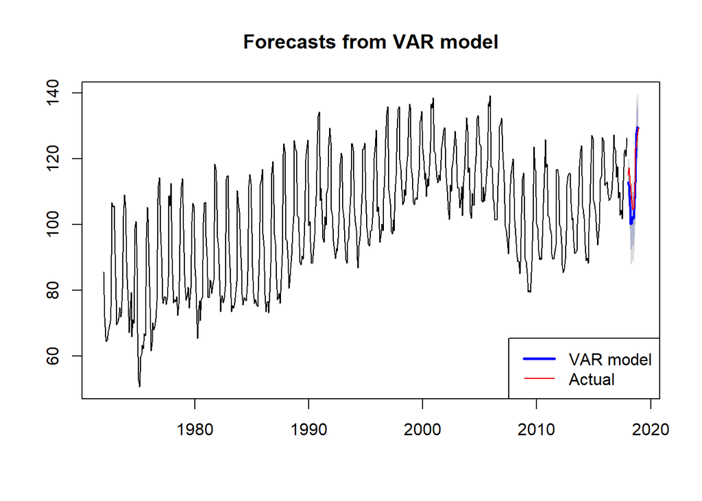

```r
# Forecast with VAR model
predict_var <- forecast(fit_var, h = 12)
# Revert back the forecasted values to the original scale
predict_var$forecast$transCandy$mean <- InvBoxCox(predict_var$forecast$transCandy$mean, lambda = lmd)
predict_var$forecast$transCandy$upper <- InvBoxCox(predict_var$forecast$transCandy$upper, lambda = lmd)
predict_var$forecast$transCandy$lower <- InvBoxCox(predict_var$forecast$transCandy$lower, lambda = lmd)
predict_var$forecast$transCandy$x <- InvBoxCox(predict_var$forecast$transCandy$x, lambda = lmd)
predict_var$forecast$transCon$mean <- InvBoxCox(predict_var$forecast$transCon$mean, lambda = lmd)
predict_var$forecast$transCon$upper <- InvBoxCox(predict_var$forecast$transCon$upper, lambda = lmd)
predict_var$forecast$transCon$lower <- InvBoxCox(predict_var$forecast$transCon$lower, lambda = lmd)
predict_var$forecast$transCon$x <- InvBoxCox(predict_var$forecast$transCon$x, lambda = lmd)

# Plot the VAR model
plot(predict_var$forecast$transCandy, main = "Forecasts from VAR model")
lines(test_ts, col = "red")
legend("bottomright",legend=c("VAR model","Actual"),col = c("blue", "red"), lwd=c(2.5,1), lty=1)
```

Calculate MAPE and MSE for VAR model to evaluate model performance.

```r
# Calculate MAPE and MSE for VAR model
MAPE_var <- 100*sum(abs(predict_var$forecast$transCandy$mean-test_ts)/test_ts)/length(test_ts)
MSE_var <- sum((predict_var$forecast$transCandy$mean-test_ts)^2)/length(test_ts)
```

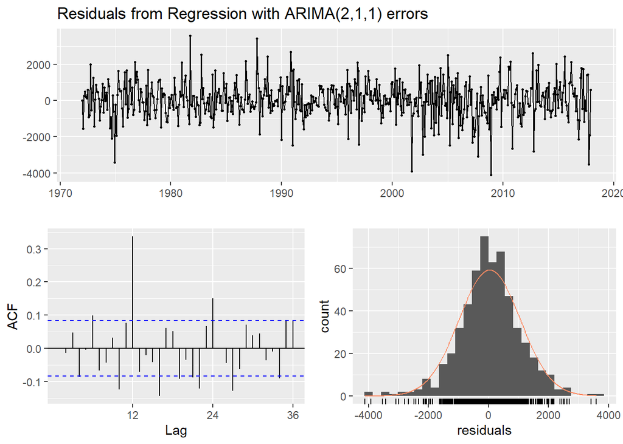

```r
# Loop thru K to find the best Fourier terms based on AICc value
bestfit <- list(aicc=Inf)
for (i in 1:6) {
  fit <- auto.arima(training_ts, d=1, xreg = BoxCox(fourier(training_ts, K=i), lambda = lmd), lambda = lmd, seasonal = FALSE)
  if (fit$aicc < bestfit$aicc)
    bestfit <- fit
}

bestfit #best Fourier terms with ARIMA errors has K=6.

# Fit Fourier terms with ARIMA errors
fit_four <- auto.arima(training_ts, d=1, xreg = BoxCox(fourier(training_ts, K=6), lambda = lmd), lambda = lmd, seasonal = FALSE)
summary(fit_four)
checkresiduals(fit_four)
```

```r
# Ljung-Box test testing residuals' white noise
Box.test(fit_four$residuals, lag = 12, type = "Ljung")
# Shapiro test testing residuals' normality
shapiro.test(fit_four$residuals)
```

```
Series: training_ts
Regression with ARIMA(2,1,1) errors
Box Cox transformation: lambda= 2.196103

Coefficients:
         ar1      ar2      ma1       S1-12      C1-12       S2-12      C2-12
      0.4555  -0.0761  -0.7870  -4516.5720  9631.0051  -3054.6726  2001.0393
s.e.  0.0644   0.0504   0.0504    241.5128   240.7734    182.2363   188.7226
           S3-12       C3-12      S4-12     C4-12     S5-12      C5-12
      -1838.9824  -2296.4194  -429.5525  309.7752  486.5775  1035.3657
s.e.    128.3425    128.2273   112.7600  116.9903  100.0698   100.2126
         C6-12
      447.6070
s.e.   66.0977

sigma^2 estimated as 1073290:  log likelihood=-4600.62
AIC=9231.24   AICc=9232.13   BIC=9295.91
Series: training_ts
Regression with ARIMA(2,1,1) errors
Box Cox transformation: lambda= 2.196103

Coefficients:
         ar1      ar2      ma1       S1-12      C1-12       S2-12      C2-12
      0.4555  -0.0761  -0.7870  -4516.5720  9631.0051  -3054.6726  2001.0393
s.e.  0.0644   0.0504   0.0504    241.5128   240.7734    182.2363   188.7226
           S3-12       C3-12      S4-12     C4-12     S5-12      C5-12
      -1838.9824  -2296.4194  -429.5525  309.7752  486.5775  1035.3657
s.e.    128.3425    128.2273   112.7600  116.9903  100.0698   100.2126
         C6-12
      447.6070
s.e.   66.0977

sigma^2 estimated as 1073290:  log likelihood=-4600.62
AIC=9231.24   AICc=9232.13   BIC=9295.91

Training set error measures:
                     ME     RMSE      MAE         MPE     MAPE      MASE
Training set 0.09249535 4.049601 3.104998 -0.04085176 3.242989 0.6067747
                   ACF1
Training set 0.03112801

    Ljung-Box test

data:  Residuals from Regression with ARIMA(2,1,1) errors
Q* = 145.08, df = 10, p-value < 2.2e-16

Model df: 14.   Total lags used: 24


    Box-Ljung test

data:  fit_four$residuals
X-squared = 91.197, df = 12, p-value = 2.898e-14


    Shapiro-Wilk normality test

data:  fit_four$residuals
W = 0.98273, p-value = 4.035e-06
```

We will plot the forecast for fourier terms with ARIMA errors model.

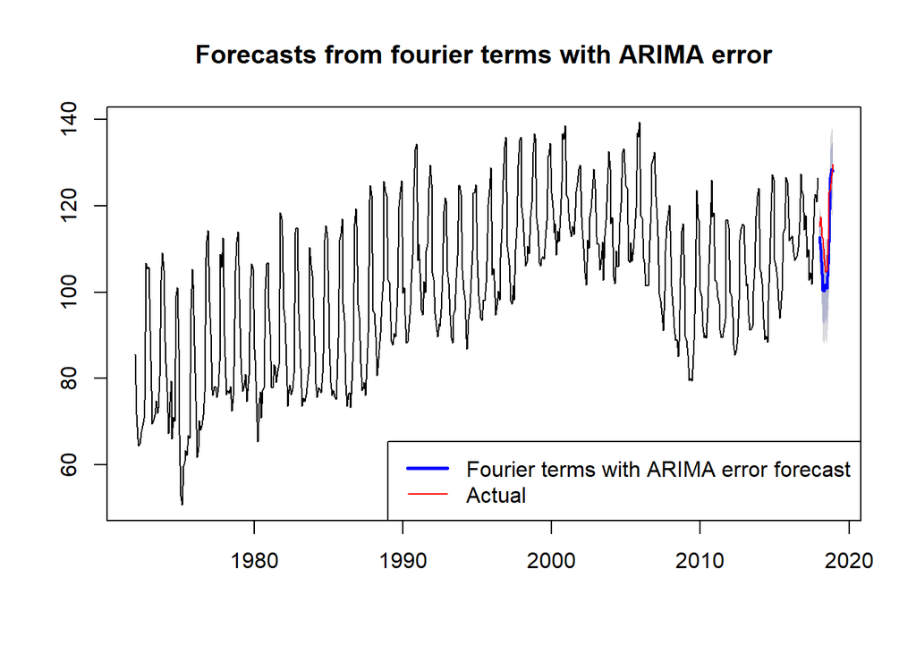

```r
# Forecast with Fourier terms with ARIMA errors
predict_four <- forecast(fit_four, xreg = BoxCox(fourier(training_ts, K=6, h = 12), lambda = lmd))

# Plot the forecasts from Fourier terms with ARIMA errors
plot(predict_four , main = "Forecasts from fourier terms with ARIMA error")
lines(test_ts, col = "red")
legend("bottomright",legend=c("Fourier terms with ARIMA error forecast","Actual"),col = c("blue", "red"), lwd=c(2.5,1), lty=1)
```

Calculate MAPE and MSE for Fourier terms with ARIMA error to evaluate model performance.

```r
# Calculate MAPE and MSE for Fourier terms with ARIMA error
MAPE_four <- 100*sum(abs(predict_four$mean-test_ts)/test_ts)/length(test_ts)
MSE_four <- sum((predict_four$mean-test_ts)^2)/length(test_ts)
```

Fit ARFIMA model and test if residuals resemble white noise. The fractional D is 0.482. The Ljung-Box test has p value less than 5%, which indicates the residuals are not white noise. The Shapiro-Wilk test has p value less than 5%, which indicates the residuals are not normally distributed.

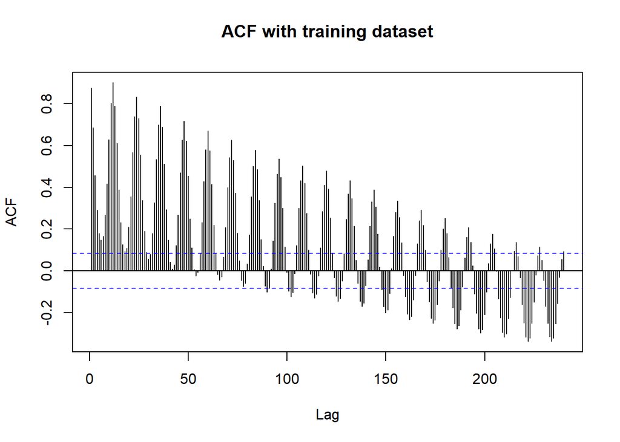

```r
# Check ACF plot for training dataset. The plot does manifest
# some long memory characteristics as the auto correlation does
# not decay quickly.
Acf(training_ts, lag.max = 240, main="ACF with training dataset")
```

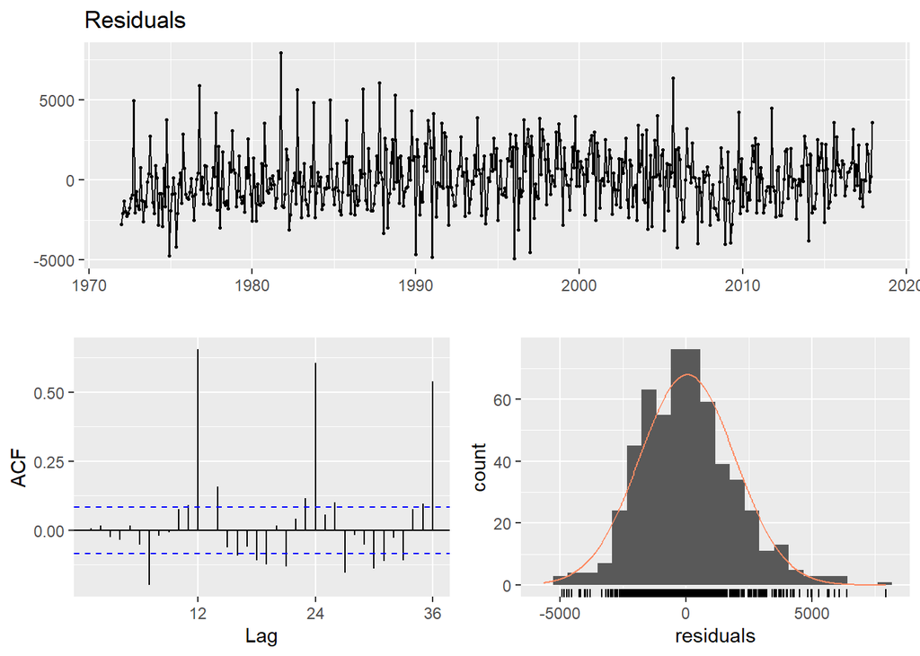

```r
# Fit ARFIMA model
fit_arfi <- arfima(training_ts, lambda = lmd)
summary(fit_arfi)
checkresiduals(fit_arfi)
```

```r
# Ljung-Box test testing residuals' white noise
Box.test(fit_arfi$residuals, lag = 12, type = "Ljung")
# Shapiro test testing residuals' normality
shapiro.test(fit_arfi$residuals)
```

```
Call:
  arfima(y = training_ts, lambda = lmd)

*** Warning during (fdcov) fit: unable to compute correlation matrix; maybe change 'h'

Coefficients:
       Estimate
d         0.482
ar.ar1    0.780
ar.ar2   -0.464
ma.ma1    0.258
ma.ma2   -0.453
ma.ma3    0.116
ma.ma4   -0.002
ma.ma5    0.441
sigma[eps] = 1880.683
[d.tol = 0.0001221, M = 100, h = 5.213e-05]
Log likelihood: -4947 ==> AIC = 9911.39 [9 deg.freedom]

    Box-Ljung test

data:  fit_arfi$residuals
X-squared = 275.4, df = 12, p-value < 2.2e-16


    Shapiro-Wilk normality test

data:  fit_arfi$residuals
W = 0.98486, p-value = 1.693e-05
```

We will plot the forecast for ARFIMA model.

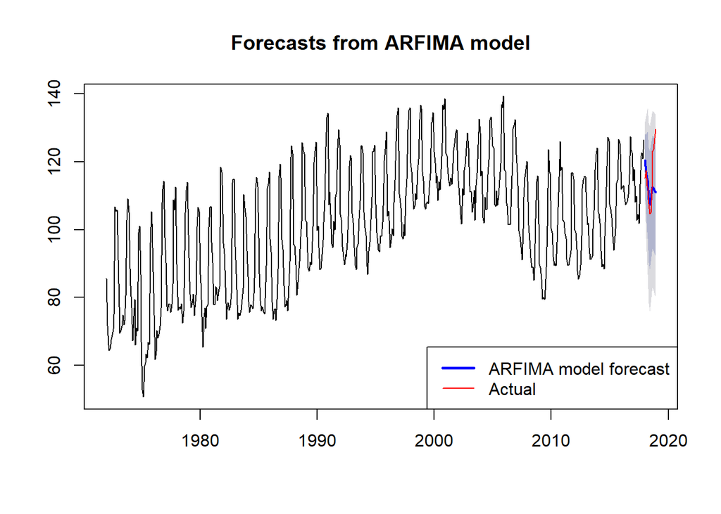

```r
# Forecast with ARFIMA model
predict_arfi <- forecast(fit_arfi, h = 12)

# Plot the forecasts from ARFIMA model
plot(predict_arfi , main = "Forecasts from ARFIMA model")
lines(test_ts, col = "red")
legend("bottomright",legend=c("ARFIMA model forecast","Actual"),col = c("blue", "red"), lwd=c(2.5,1), lty=1)
```

Calculate MAPE and MSE for ARFIMA model to evaluate model performance.

```r
# Calculate MAPE and MSE for ARFIMA model
MAPE_arfi <- 100*sum(abs(predict_arfi$mean-test_ts)/test_ts)/length(test_ts)
MSE_arfi <- sum((predict_arfi$mean-test_ts)^2)/length(test_ts)
```

Fit TBATS model and test if residuals resemble white noise. The order of the model is TBATS(1, {1,3}, -, {<12,5>}). The Ljung-Box test has p value less than 5%, which indicates the residuals are not white noise. The Shapiro-Wilk test has p value less than 5%, which indicates the residuals are not normally distributed.

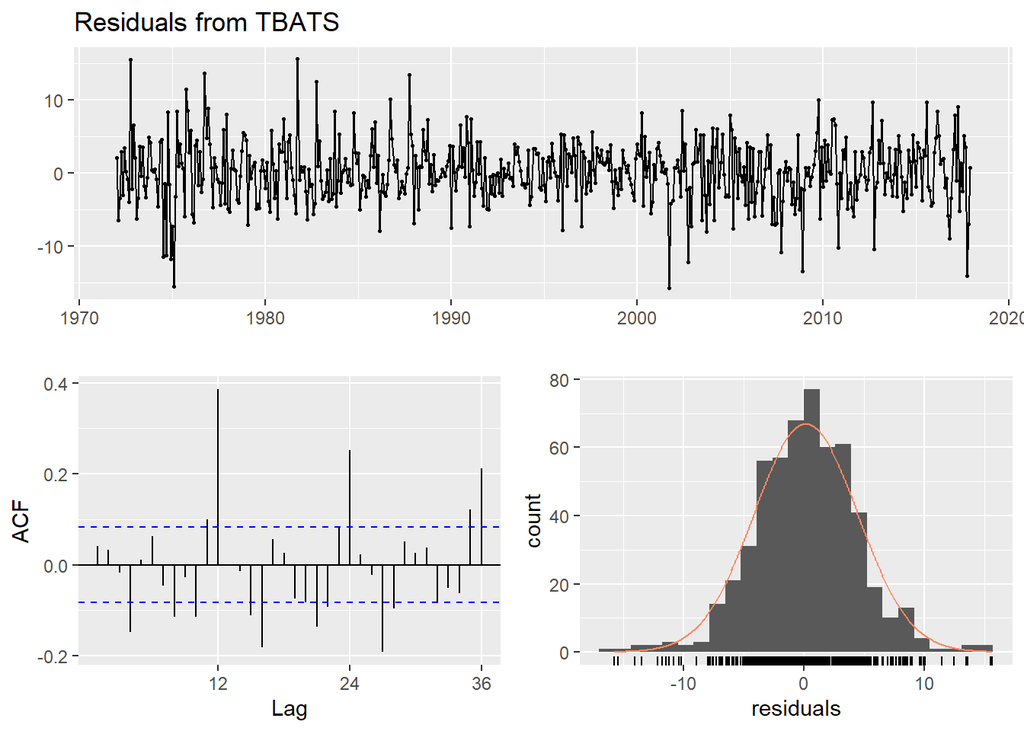

```r
# Fit TBATS model
fit_tb <- tbats(training_ts)
summary(fit_tb)
checkresiduals(fit_tb)
```

```r
# Ljung-Box test testing residuals' white noise
Box.test(residuals(fit_tb), lag = 12, type = "Ljung")
# Shapiro test testing residuals' normality
shapiro.test(residuals(fit_tb))
```

```
                  Length Class  Mode
lambda               0   -none- NULL
alpha                1   -none- numeric
beta                 0   -none- NULL
damping.parameter    0   -none- NULL
gamma.one.values     1   -none- numeric
gamma.two.values     1   -none- numeric
ar.coefficients      1   -none- numeric
ma.coefficients      3   -none- numeric
likelihood           1   -none- numeric
optim.return.code    1   -none- numeric
variance             1   -none- numeric
AIC                  1   -none- numeric
parameters           2   -none- list
seed.states         15   -none- numeric
fitted.values      552   ts     numeric
errors             552   ts     numeric
x                 8280   -none- numeric
seasonal.periods     1   -none- numeric
k.vector             1   -none- numeric
y                  552   ts     numeric
p                    1   -none- numeric
q                    1   -none- numeric
call                 2   -none- call
series               1   -none- character
method               1   -none- character

    Ljung-Box test

data:  Residuals from TBATS
Q* = 214.84, df = 3, p-value < 2.2e-16

Model df: 22.   Total lags used: 25


    Box-Ljung test

data:  residuals(fit_tb)
X-squared = 122.33, df = 12, p-value < 2.2e-16


    Shapiro-Wilk normality test

data:  residuals(fit_tb)
W = 0.98722, p-value = 9.285e-05
```

We will plot the forecast for TBATS model.

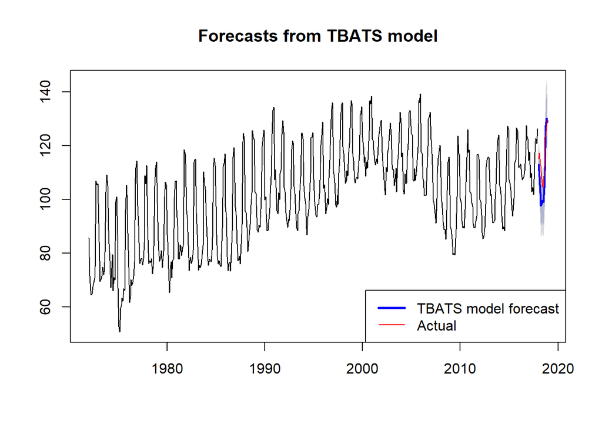

```r
# Forecast with TBATS model
predict_tb <- forecast(fit_tb, h = 12)

# Plot the forecasts from TBATS model
plot(predict_tb , main = "Forecasts from TBATS model")
lines(test_ts, col = "red")
legend("bottomright",legend=c("TBATS model forecast","Actual"),col = c("blue", "red"), lwd=c(2.5,1), lty=1)
```

Calculate MAPE and MSE for TBATS model to evaluate model performance.

```r
# Calculate MAPE and MSE for TBATS model
MAPE_tb <- 100*sum(abs(predict_tb$mean-test_ts)/test_ts)/length(test_ts)
MSE_tb <- sum((predict_tb$mean-test_ts)^2)/length(test_ts)
```

Fit intervention model and test if residuals resemble white noise. The order of arima part is ARIMA(3,1,3)(0,1,2)[12]. For the intervention specification, I tend to model in a way that match the mean of the original plot. The Ljung-Box test has p value greater than 5%, which indicates the residuals are white noise. The Shapiro-Wilk test has p value less than 5%, which indicates the residuals are not normally distributed.

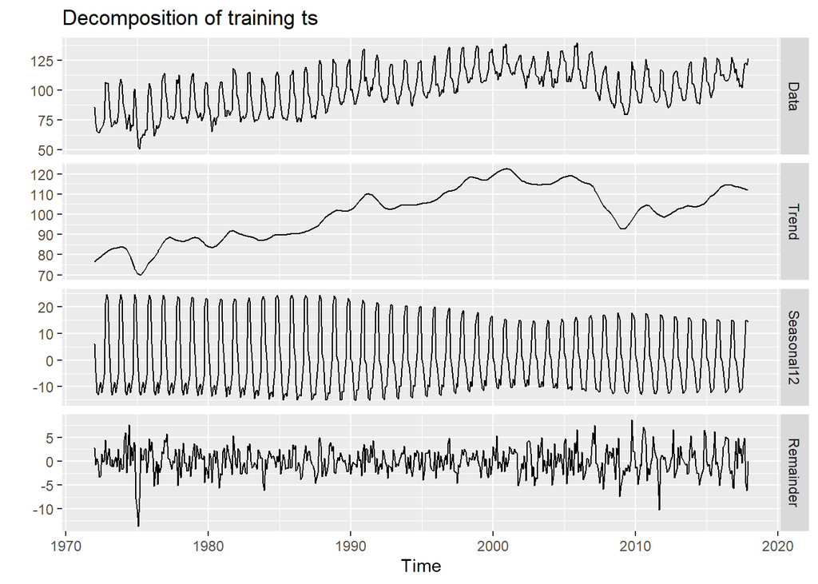

```r
# Plot decomposition of training ts
autoplot(mstl(training_ts), main="Decomposition of training ts")
```

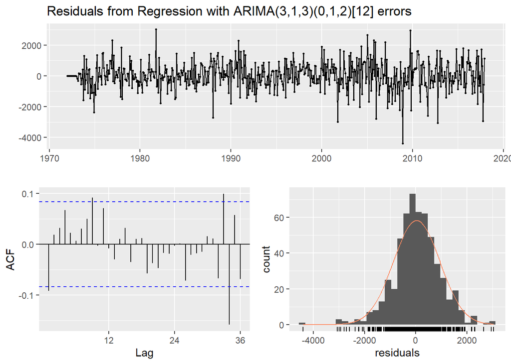

```r
# Fit intervention model. The best model is picked for trace outputs.
fit_intv <- Arima(training_ts, order = c(3,1,3), seasonal = c(0,1,2), xreg = ts(c(1:344,seq(344, 106, by = -2),106:193), start=c(1972,1), frequency=12), lambda = lmd)
summary(fit_intv)
checkresiduals(fit_intv)
```

```r
# Ljung-Box test testing residuals' white noise
Box.test(fit_intv$residuals, lag = 12, type = "Ljung")
# Shapiro test testing residuals' normality
shapiro.test(fit_intv$residuals)
```

```
Series: training_ts
Regression with ARIMA(3,1,3)(0,1,2)[12] errors
Box Cox transformation: lambda= 2.196103

Coefficients:
          ar1      ar2     ar3     ma1      ma2      ma3     sma1     sma2
      -0.4200  -0.1509  0.7349  0.1768  -0.1379  -0.9776  -0.6544  -0.1264
s.e.   0.0425   0.0485  0.0426  0.0180   0.0199   0.0402   0.0450   0.0433
         xreg
      30.8078
s.e.   6.3635

sigma^2 estimated as 860416:  log likelihood=-4452.28
AIC=8924.56   AICc=8924.98   BIC=8967.46

Training set error measures:
                    ME     RMSE      MAE          MPE     MAPE      MASE
Training set 0.1025659 3.519821 2.677351 -0.001972641 2.729397 0.5232046
                    ACF1
Training set -0.07386339

    Ljung-Box test

data:  Residuals from Regression with ARIMA(3,1,3)(0,1,2)[12] errors
Q* = 24.174, df = 15, p-value = 0.06219

Model df: 9.   Total lags used: 24


    Box-Ljung test

data:  fit_intv$residuals
X-squared = 17.881, df = 12, p-value = 0.1193


    Shapiro-Wilk normality test

data:  fit_intv$residuals
W = 0.98073, p-value = 1.135e-06
```

Check if overfitting problem exists when fitting intervention model.  
As we can tell, the coefficients change after decreasing p or q by 1. The model assumption is changed if coefficients change. Therefore, we conclude the overfitting problem does not exist in the fitted intervention model.

```r
# Decrease q by 1
fit_intvA <- Arima(training_ts, order = c(3,1,2), seasonal = c(0,1,2), xreg = ts(c(1:344,seq(344, 106, by = -2),106:193), start=c(1972,1), frequency=12), lambda = lmd)
summary(fit_intvA)
# Decrease p by 1
fit_intvB <- Arima(training_ts, order = c(2,1,3), seasonal = c(0,1,2), xreg = ts(c(1:344,seq(344, 106, by = -2),106:193), start=c(1972,1), frequency=12), lambda = lmd)
summary(fit_intvB)
```

```
Series: training_ts
Regression with ARIMA(3,1,2)(0,1,2)[12] errors
Box Cox transformation: lambda= 2.196103

Coefficients:
         ar1     ar2     ar3      ma1     ma2     sma1     sma2     xreg
      0.3848  0.2153  0.1547  -0.7733  -0.218  -0.6350  -0.1517  26.7178
s.e.  0.3097  0.1990  0.0593   0.3130   0.308   0.0442   0.0432   8.0348

sigma^2 estimated as 901285:  log likelihood=-4463.39
AIC=8944.78   AICc=8945.12   BIC=8983.39

Training set error measures:
                    ME    RMSE      MAE        MPE     MAPE      MASE
Training set 0.1339781 3.59258 2.711386 0.03050823 2.756793 0.5298556
                   ACF1
Training set 0.02367838
Series: training_ts
Regression with ARIMA(2,1,3)(0,1,2)[12] errors
Box Cox transformation: lambda= 2.196103

Coefficients:
          ar1     ar2      ma1      ma2     ma3     sma1     sma2     xreg
      -0.0618  0.7921  -0.3379  -0.9374  0.2826  -0.6132  -0.1657  25.9801
s.e.   0.0746  0.0595   0.0936   0.0578  0.0653   0.0445   0.0429   9.8871

sigma^2 estimated as 901530:  log likelihood=-4463.65
AIC=8945.3   AICc=8945.64   BIC=8983.91

Training set error measures:
                    ME     RMSE      MAE       MPE     MAPE      MASE
Training set 0.1360582 3.605144 2.736585 0.0310897 2.787987 0.5347801
                   ACF1
Training set 0.02845551
```

We will plot the forecast for intervention model.

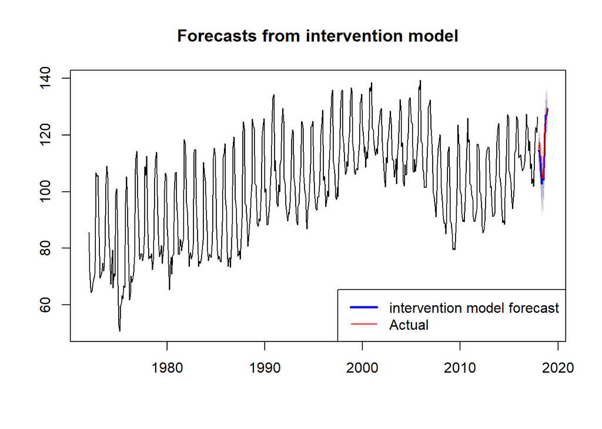

```r
# Forecast with intervention model
predict_intv <- forecast(fit_intv, xreg = ts(193:204, start=c(2018,1), frequency=12), h = 12)

# Plot the forecasts from intervention model
plot(predict_intv , main = "Forecasts from intervention model")
lines(test_ts, col = "red")
legend("bottomright",legend=c("intervention model forecast","Actual"),col = c("blue", "red"), lwd=c(2.5,1), lty=1)
```

Calculate MAPE and MSE for intervention model to evaluate model performance.

```r
# Calculate MAPE and MSE for intervention model
MAPE_intv <- 100*sum(abs(predict_intv$mean-test_ts)/test_ts)/length(test_ts)
MSE_intv <- sum((predict_intv$mean-test_ts)^2)/length(test_ts)
```

Aggregate model performance measurements together.

```r
error_table <- as.data.frame(rbind(c(round(MAPE_arima,4),round(MSE_arima,4),round(fit_arima$aicc,4),"YES","YES"),
                                   c(round(MAPE_ets,4),round(MSE_ets,4),round(fit_ets$aicc,4),"NO","N/A"),
                                   c(round(MAPE_lm,4),round(MSE_lm,4),round(extractAIC(fit_lm)[2],4),"NO","YES"),
                                   c(round(MAPE_xreg,4),round(MSE_xreg,4),round(fit_xreg$aicc,4),"YES","NO"),
                                   c(round(MAPE_var,4),round(MSE_var,4),round(AICs[4],4),"NO","NO"),
                                   c(round(MAPE_four,4),round(MSE_four,4),round(fit_four$aicc,4),"NO","NO"),
                                   c(round(MAPE_arfi,4),round(MSE_arfi,4),round(summary(fit_arfi)$aic,4),"NO","N/A"),
                                   c(round(MAPE_tb,4),round(MSE_tb,4),round(fit_tb$AIC,4),"NO","N/A"),
                                   c(round(MAPE_intv,4),round(MSE_intv,4),round(fit_intv$aicc,4),"YES","YES")), row.names = c("Arima model","ETS model","Linear regression",
                                                                                          "regr model (ARIMA errs)","VAR model",
                                                                                          "Fourier mdl (ARIMA errs)","ARFIMA model",
                                                                                          "TBATS model","intervention model"))
colnames(error_table) <- c("MAPE","MSE","AICc/AIC","Residual white noise","Coefficient significance")
error_table
```

```
                           MAPE     MSE   AICc/AIC Residual white noise
Arima model              2.6945 12.8972  8955.7543                  YES
ETS model                4.6519 35.4344 11127.9183                   NO
Linear regression        6.0806 64.3476  9114.1805                   NO
regr model (ARIMA errs)  2.4889 11.4796  8956.8447                  YES
VAR model                4.4665 37.8804     5.2873                   NO
Fourier mdl (ARIMA errs) 4.9885 45.5128  9232.1331                   NO
ARFIMA model             5.1121 74.6922  9911.3901                   NO
TBATS model              6.2099 67.0149  5140.6433                   NO
intervention model       1.7881  7.2042  8924.9753                  YES
                         Coefficient significance
Arima model                                   YES
ETS model                                     N/A
Linear regression                             YES
regr model (ARIMA errs)                        NO
VAR model                                      NO
Fourier mdl (ARIMA errs)                       NO
ARFIMA model                                  N/A
TBATS model                                   N/A
intervention model                            YES
```

So for model evaluation, our first criteria is the residuals must resemble white noise. Given this, only three models are left. They are Arima model, regression model with ARIMA errors and intervention model.  
We will add another metric called coefficient significance. That is, whether all the coefficients in the model are significant or not. We will only accept model that all the coefficients are significant.  
Next, we will look at the corresponding MAPE and MSE and determine which one is our final selection. Here the rank of importance of these metrics from high to low are MAPE and MSE. Our final model is intervention model given its best performance in MAPE and MSE, and in AICc compared with ARIMA and regression model with ARIMA errors.  
Note although we include AICc/AIC for all the models, they are not comparable as AICc/AIC involve a constant that different fitting algorithms set to different values. The only time that AICc/AIC is comparable is when the underlying method for different models are the same, such as ARIMA, regression model with ARIMA errors, fourier model with ARIMA errors and intervention model.

```r
error_table_final <- error_table[c("Arima model","regr model (ARIMA errs)","intervention model"),]
error_table_final
```

```
                          MAPE     MSE  AICc/AIC Residual white noise
Arima model             2.6945 12.8972 8955.7543                  YES
regr model (ARIMA errs) 2.4889 11.4796 8956.8447                  YES
intervention model      1.7881  7.2042 8924.9753                  YES
                        Coefficient significance
Arima model                                  YES
regr model (ARIMA errs)                       NO
intervention model                           YES
```

We still have room for improvement. For example, we can apply expanding or sliding windows to further enhance the model performance.

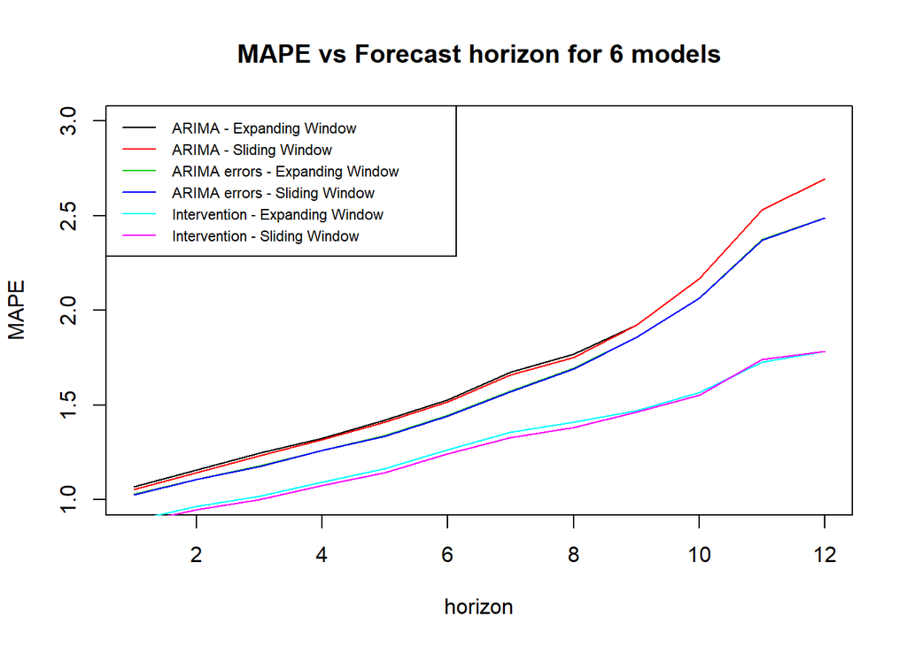

```r
## Set up parameters
k <- length(training_ts) # minimum data length for fitting a model
n <- length(candy_ts) # Number of data points
p <- 12 ### Period
H <- 12 # Forecast Horiz
defaultW <- getOption("warn")
options(warn = -1)
st <- tsp(candy_ts)[1]+(k-2)/p #  gives the start time in time units

# Set up MAPE, MSE and AICc matrix for each model
mape_1 <- matrix(NA,n-k,H)
mape_2 <- matrix(NA,n-k,H)
mape_3 <- matrix(NA,n-k,H)
mape_4 <- matrix(NA,n-k,H)
mape_5 <- matrix(NA,n-k,H)
mape_6 <- matrix(NA,n-k,H)
mse_1 <- matrix(NA,n-k,H)
mse_2 <- matrix(NA,n-k,H)
mse_3 <- matrix(NA,n-k,H)
mse_4 <- matrix(NA,n-k,H)
mse_5 <- matrix(NA,n-k,H)
mse_6 <- matrix(NA,n-k,H)
aicc_1 <- matrix(NA,n-k,H)
aicc_2 <- matrix(NA,n-k,H)
aicc_3 <- matrix(NA,n-k,H)
aicc_4 <- matrix(NA,n-k,H)
aicc_5 <- matrix(NA,n-k,H)
aicc_6 <- matrix(NA,n-k,H)


# Loop through all folds to obtain MAE, RMSE and AICc
for(i in 1:(n-k))
{
  ### One Month rolling forecasting
  # Expanding Window
  train_1 <- window(candy_ts, end=st + i/p)  ## Window Length: k+i

  # Sliding Window - keep the training window of fixed length.
  # The training set always consists of k observations.
  train_2 <- window(candy_ts, start=st+(i-k+1)/p, end=st+i/p) ## Window Length: k
  test <- window(candy_ts, start=st + (i+1)/p, end=st + (i+H)/p) ## Window Length: H

  # Fit 6 models
  fit_1 <- Arima(train_1, order = c(2,1,2), seasonal = c(0,1,2), lambda = lmd)
  fcast_1 <- forecast(fit_1, h=H)
  fit_2 <- Arima(train_2, order = c(2,1,2), seasonal = c(0,1,2), lambda = lmd)
  fcast_2 <- forecast(fit_2, h=H)
  fit_3 <- Arima(train_1, order = c(2,1,2), seasonal = c(0,1,2), xreg = BoxCox(window(consumption_ts, end=st + i/p), lambda = lmd1), lambda = lmd)
  fcast_3 <- forecast(fit_3, xreg = BoxCox(test_con_ts, lambda = lmd1), h = H)
  fit_4 <- Arima(train_2, order = c(2,1,2), seasonal = c(0,1,2), xreg = BoxCox(window(consumption_ts, start=st+(i-k+1)/p, end=st+i/p), lambda = lmd1), lambda = lmd)
  fcast_4 <- forecast(fit_4, xreg = BoxCox(test_con_ts, lambda = lmd1), h = H)
  fit_5 <- Arima(train_1, order = c(3,1,3), seasonal = c(0,1,2), xreg = window(ts(c(1:344,seq(344, 106, by = -2),106:193,193:204), start=c(1972,1), frequency=12), end=st + i/p), lambda = lmd, method="ML")
  fcast_5 <- forecast(fit_5, xreg = ts(193:204, start=c(2018,1), frequency=12), h = H)
  fit_6 <- Arima(train_2, order = c(3,1,3), seasonal = c(0,1,2), xreg = window(ts(c(1:344,seq(344, 106, by = -2),106:193,193:204), start=c(1972,1), frequency=12), start=st+(i-k+1)/p, end=st+i/p), lambda = lmd, method="ML")
  fcast_6 <- forecast(fit_6, xreg = ts(193:204, start=c(2018,1), frequency=12), h = H)
  # Calculate MAPE, RMSE and AICc
  mape_1[i,1:length(test)] <- 100*sum(abs(fcast_1[['mean']]-test)/test)/H
  mape_2[i,1:length(test)] <- 100*sum(abs(fcast_2[['mean']]-test)/test)/H
  mape_3[i,1:length(test)] <- 100*sum(abs(fcast_3[['mean']]-test)/test)/H
  mape_4[i,1:length(test)] <- 100*sum(abs(fcast_4[['mean']]-test)/test)/H
  mape_5[i,1:length(test)] <- 100*sum(abs(fcast_5[['mean']]-test)/test)/H
  mape_6[i,1:length(test)] <- 100*sum(abs(fcast_6[['mean']]-test)/test)/H

  mse_1[i,1:length(test)] <- sum((fcast_1[['mean']]-test)^2)/H
  mse_2[i,1:length(test)] <- sum((fcast_2[['mean']]-test)^2)/H
  mse_3[i,1:length(test)] <- sum((fcast_3[['mean']]-test)^2)/H
  mse_4[i,1:length(test)] <- sum((fcast_4[['mean']]-test)^2)/H
  mse_5[i,1:length(test)] <- sum((fcast_5[['mean']]-test)^2)/H
  mse_6[i,1:length(test)] <- sum((fcast_6[['mean']]-test)^2)/H

  aicc_1[i,1:length(test)] <- fit_1$aicc
  aicc_2[i,1:length(test)] <- fit_2$aicc
  aicc_3[i,1:length(test)] <- fit_3$aicc
  aicc_4[i,1:length(test)] <- fit_4$aicc
  aicc_5[i,1:length(test)] <- fit_5$aicc
  aicc_6[i,1:length(test)] <- fit_6$aicc
}

# Plot MAPE vs Forecast horizon
win.graph(width=6, height=4.5,pointsize=12)
plot(1:12, colMeans(mape_1,na.rm=TRUE), type="l",col=1,xlab="horizon", ylab="MAPE",
     ylim=c(1,3), main="MAPE vs Forecast horizon for 6 models")
lines(1:12, colMeans(mape_2,na.rm=TRUE), type="l",col=2)
lines(1:12, colMeans(mape_3,na.rm=TRUE), type="l",col=3)
lines(1:12, colMeans(mape_4,na.rm=TRUE), type="l",col=4)
lines(1:12, colMeans(mape_5,na.rm=TRUE), type="l",col=5)
lines(1:12, colMeans(mape_6,na.rm=TRUE), type="l",col=6)
legend("topleft",legend=c("ARIMA - Expanding Window","ARIMA - Sliding Window",
                          "ARIMA errors - Expanding Window", "ARIMA errors - Sliding Window",
                          "Intervention - Expanding Window","Intervention - Sliding Window"),col=1:6,lty=1,
       cex=0.7, pt.cex = 1)
```